# IDS investigation worksheet - PULL BEFORE EDITING GUYS!!!

by The Code Crunchers: Gigi, Ben, Jamie & Adam

2024-12-01

**Note:** You can use this file as you ‘working document’ where you can try out various investigation ideas and keep notes about your findings. How you use and structure this file is up to you. It is recommended that you keep notes about what you are investigating and what you find as this will make the process of creating your presentation and report easier. Please note that you *do not* need to submit this file as part of your group project.

```r
library(tidyverse)
library(tidymodels)
laptop_data <- read_csv("data/laptop_data_cleaned.csv")
```

### Data Cleaning and that

```r
laptop_data <- laptop_data%>%
  mutate(,
storage_type = case_when(
    HDD == 0 ~ "ssd",
    SSD == 0 ~ "hdd",
    .default = "both"
  ))
```

```r
laptop_data_untidy <- read.csv("data/laptop_data.csv")
laptop_data_untidy <- laptop_data_untidy%>%
  mutate(Ram = parse_number(Ram))
laptop_data_untidy <- laptop_data_untidy%>%
  mutate(Weight = parse_number(Weight))
laptop_data_untidy <- laptop_data_untidy%>%
  mutate(Second_Price = Price)
laptop_data_filtered <- laptop_data_untidy [-1192, ]
laptop_data_filtered <- laptop_data_filtered[1:1273, ]

#check
first_diff <- which(!(laptop_data$Company == laptop_data_filtered$Company & laptop_data$TypeName == laptop_data_filtered$TypeName & laptop_data$Ram == laptop_data_filtered$Ram ))
second_diff <- all(abs(laptop_data$Weight - laptop_data_filtered$Weight) < .Machine$double.eps^0.5)

##view(select(laptop_data_filtered, Ram, Weight, Company, TypeName))
##view(select(laptop_data, Ram, Weight, Company, TypeName))
##print(first_diff)
##print(second_diff)

laptop_data_merged <- cbind(laptop_data, select(laptop_data_filtered, Second_Price, Inches, ScreenResolution, Cpu, Gpu, Memory))
```

```r
laptop_data_tidy <- laptop_data_merged %>%
  mutate(,
         storage_capacity = HDD + SSD
         )
```

```r
laptop_data_tidy <- laptop_data_tidy%>%
  filter(,storage_capacity != 0)
#From the work Adams done, it looks like when storage_capacity = 0 that often that these laptops do have storage but its just like flash storage and I don't know if we should just get rid or them or not but thought I'd at least say x.
```

```r
full_company_list <- laptop_data_tidy %>%
  count(Company) %>%
  arrange(n)
```

```r
laptop_data_tidy <- laptop_data_tidy %>%
  group_by(Company) %>%
    mutate(
      Company = case_when(
        n() > 100 ~ Company,
        TRUE ~ "Other"
      )
    ) %>%
  ungroup()
```

```r
laptop_data_tidy <-laptop_data_tidy %>%
 mutate(
        log_price = log(round(exp(Price) * 0.0094 , digits =2)),
        Price = round(exp(log_price),digits = 2)
         )


laptop_data_final <- laptop_data_tidy

laptop_data_final<-select(laptop_data_final,-Second_Price,)
```

```r
laptop_data_final <- laptop_data_final%>%
  mutate(GHz = as.numeric(str_extract(Cpu, "\\d+(\\.\\d+)?(?=GHz)")))
```

```r
write_csv(laptop_data_final, "data/laptop_data_final.csv")
```

### Data Visualisation and exploring

```r
laptop_data_final %>%
  summarise(across(everything(), ~sum(is.na(.))))
```

```
## # A tibble: 1 × 22
##   Company TypeName   Ram Weight Price TouchScreen   Ips   Ppi Cpu_brand   HDD
##     <int>    <int> <int>  <int> <int>       <int> <int> <int>     <int> <int>
## 1       0        0     0      0     0           0     0     0         0     0
## # ℹ 12 more variables: SSD <int>, Gpu_brand <int>, Os <int>,
## #   storage_type <int>, Inches <int>, ScreenResolution <int>, Cpu <int>,
## #   Gpu <int>, Memory <int>, storage_capacity <int>, log_price <int>, GHz <int>
```

```r
#there are no NA values

laptop_data_final %>%
  select(Ram, Weight, Price, Ppi, HDD, SSD,storage_capacity,Inches,log_price,GHz) %>%
  summarise(
    across(
      .cols = everything(),
      .fns = list(
        min = ~min(. , na.rm = TRUE),
        mean = ~mean(. , na.rm = TRUE),
        median = ~median(. , na.rm = TRUE),
        max = ~max(. , na.rm = TRUE)
      )
    )
  ) %>%
  pivot_longer(
    cols = everything(),
    names_to = c("Statistic", "Variable"),
    names_pattern = "(.*)_(.*)",
    values_to = "Value"
  ) %>%
  pivot_wider(names_from = Variable, values_from = Value)
```

```
## # A tibble: 10 × 5
##    Statistic          min   mean median     max
##    <chr>            <dbl>  <dbl>  <dbl>   <dbl>
##  1 Ram               2      8.68   8      64
##  2 Weight            0.81   2.08   2.08    4.7
##  3 Price            87.1  588.   510.   3055.
##  4 Ppi              90.6  147.   141.    352.
##  5 HDD               0    440.     0    2000
##  6 SSD               0    198.   256    1024
##  7 storage_capacity  8    639.   500    2512
##  8 Inches           11.3   15.1   15.6    18.4
##  9 log_price         4.47   6.21   6.23    8.02
## 10 GHz               0.9    2.35   2.5     3.6
```

```r
# Calculating correlations
correlation_matrix <- laptop_data_final %>%
  select_if(is.numeric) %>%
  cor(use = "complete.obs")





#closer to 1 = greater the correlation
```

**Notes:**

```r
#in this chunk I want to gain more insight on the characteristics of the different laptop types to indicate if the existence of certain variables increase the likelihood of what laptop type the device is

laptop_data_final %>%
  count(TypeName)
```

```
## # A tibble: 6 × 2
##   TypeName               n
##   <chr>              <int>
## 1 2 in 1 Convertible   103
## 2 Gaming               203
## 3 Netbook               12
## 4 Notebook             667
## 5 Ultrabook            182
## 6 Workstation           29
```

```r
#Calculating the average values for each laptop type
avg_stats <- laptop_data_final %>%
  group_by(TypeName) %>%
  summarise(
    Avg_Ram = mean(Ram, na.rm = TRUE),
    Avg_Weight = mean(Weight, na.rm = TRUE),
    Avg_Price = mean(Price, na.rm = TRUE),
    Avg_Ppi = mean(Ppi, na.rm = TRUE),
    Avg_HDD = mean(HDD, na.rm = TRUE),
    Avg_SSD = mean(SSD, na.rm = TRUE),
    Avg_log_price = mean(log_price, na.rm = TRUE),
    Avg_Inches = mean(Inches, na.rm = TRUE),
    Avg_Storage_Capacity = mean(storage_capacity, na.rm = TRUE),
    Avg_GHz = mean(GHz, na.rm = TRUE),
  )
print(avg_stats)
```

```
## # A tibble: 6 × 11
##   TypeName    Avg_Ram Avg_Weight Avg_Price Avg_Ppi Avg_HDD Avg_SSD Avg_log_price
##   <chr>         <dbl>      <dbl>     <dbl>   <dbl>   <dbl>   <dbl>         <dbl>
## 1 2 in 1 Con…    9.18       1.61      698.    180.   150.     313.          6.45
## 2 Gaming        14.1        2.95      871.    144.   867.     238.          6.68
## 3 Netbook        6.17       1.42      515.    147.     0      228           5.99
## 4 Notebook       6.68       2.08      407.    132.   487.     129.          5.89
## 5 Ultrabook      9.53       1.35      787.    185.    24.7    332.          6.62
## 6 Workstation   10.5        2.47     1142.    157.   190.     264.          7.00
## # ℹ 3 more variables: Avg_Inches <dbl>, Avg_Storage_Capacity <dbl>,
## #   Avg_GHz <dbl>
```

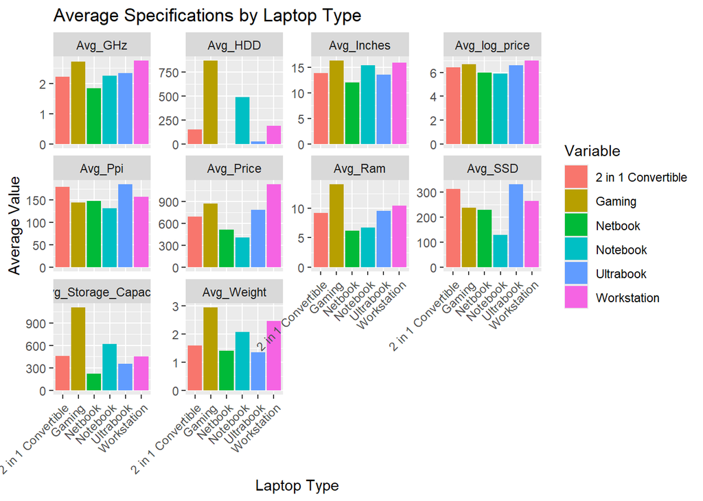

```r
avg_stats_long <- avg_stats %>%
  pivot_longer(cols = starts_with("Avg_"), names_to = "Variable", values_to = "Value")

#Creating a bunch of bar charts
ggplot(avg_stats_long, aes(x = TypeName, y = Value, fill = TypeName)) +
  geom_bar(stat = "identity", position = position_dodge()) +
  facet_wrap(~Variable, scales = "free_y") +
  labs(
    title = "Average Specifications by Laptop Type",
    x = "Laptop Type",
    y = "Average Value",
    fill = "Variable"
  ) +
  theme(axis.text.x = element_text(angle = 45, hjust = 1))
```

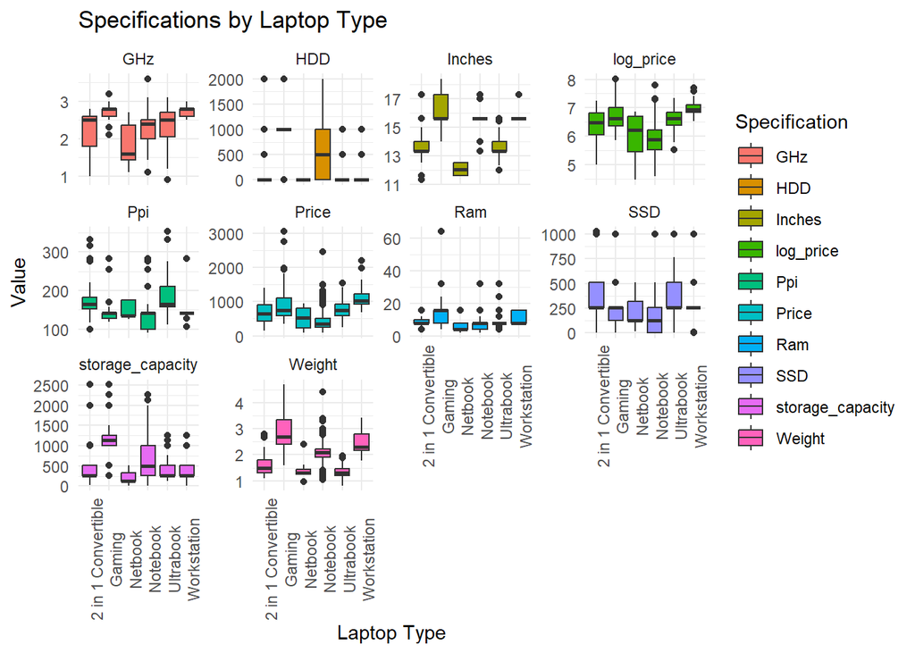

```r
#on to box plots now
variables <- c("Ram", "Weight", "Price", "Ppi", "HDD", "SSD","Log Price","Storage Capacity","Inches","GHz")

avg_stats_long <- laptop_data_final %>%
  select(TypeName, Ram, Weight, Price, Ppi, HDD, SSD, log_price, storage_capacity, Inches,GHz) %>%
  pivot_longer(
    cols = Ram:GHz,
    names_to = "Variable",
    values_to = "Value"
  )

# visualising the box plots
ggplot(avg_stats_long, aes(x = TypeName, y = Value, fill = Variable)) +
  geom_boxplot() +
  facet_wrap(~Variable, scales = "free_y") +
  theme_minimal() +
  labs(
    title = "Specifications by Laptop Type",
    x = "Laptop Type",
    y = "Value",
    fill = "Specification"
  ) +
  theme(axis.text.x = element_text(angle = 90))
```

### Discoveries:

**2-in-1 Convertible**

• Specifications: Moderate specifications across all categories.

• HDD & SSD: Limited HDD capacity, but average SSD storage.

• Weight: Lightweight, making it portable.

• Price: Mid-range pricing compared to other categories.

• Usage: Suitable for users prioritizing portability and versatility without requiring high-end performance.

**Gaming**

• Specifications: High RAM and large HDD capacity.

• Price: On the higher end.

• Weight: Among the heaviest laptops due to extensive components.

• Usage: Ideal for gamers or users needing high processing power for tasks eg 3D modeling or video editing.

**Netbook**

• Weight: Very lightweight and portable.

• Usage: Suitable for basic tasks such as web browsing and document editing.

**Notebook**

• Weight: Medium weight.

• Usage: Designed for students and professionals seeking an all-purpose laptop.

**Ultrabook**

• Price: Premium-priced due to sleek design and portability.

• Weight: One of the lightest laptop types.

• Usage: Best for business professionals who value portability and premium build quality.

**Workstation**

• Price: The most expensive category due to professional-grade hardware.

• Weight: Heavy, reflecting the high-end components.

• Usage: Suitable for heavy workloads, such as software development, simulations, and engineering tasks.

```r
 # laptop_data_final %>%
  #ggplot(,mapping = aes(x=,y=y_axis)) +
  #geom_point() +
  #geom_smooth( method = "lm")+
# theme_minimal() +
 # labs(
   # title = title,
#  )
```

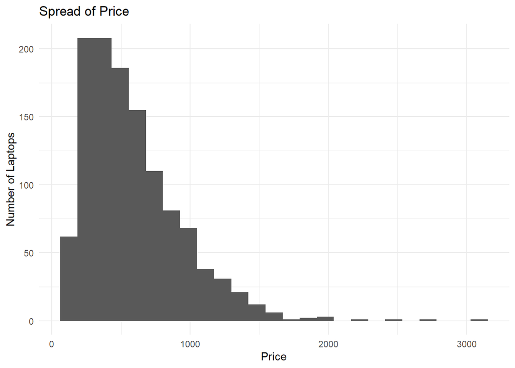

```r
laptop_data_final %>%
  ggplot(mapping = aes(x=Price)) +
  geom_histogram(bins = 25)+
  theme_minimal() +
  labs(
    title = "Spread of Price",
    x = "Price",
    y = "Number of Laptops"
  )
```

```r
#Most laptops are around 100-1000 then steadily decreases
```

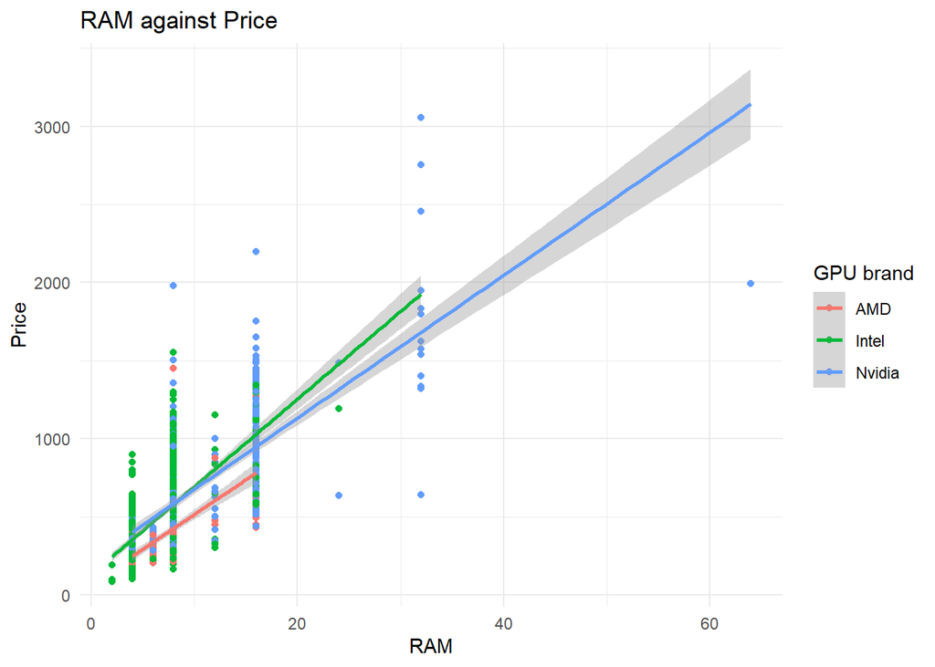

```r
laptop_data_final %>%
  ggplot(mapping = aes(x=Ram,y=Price, color=factor(Gpu_brand))) +
  geom_point() +
  geom_smooth(, method = "lm", )+
  theme_minimal() +
  labs(
    title = "RAM against Price",
    x = "RAM",
    y = "Price",
    color = "GPU brand"
  )
```

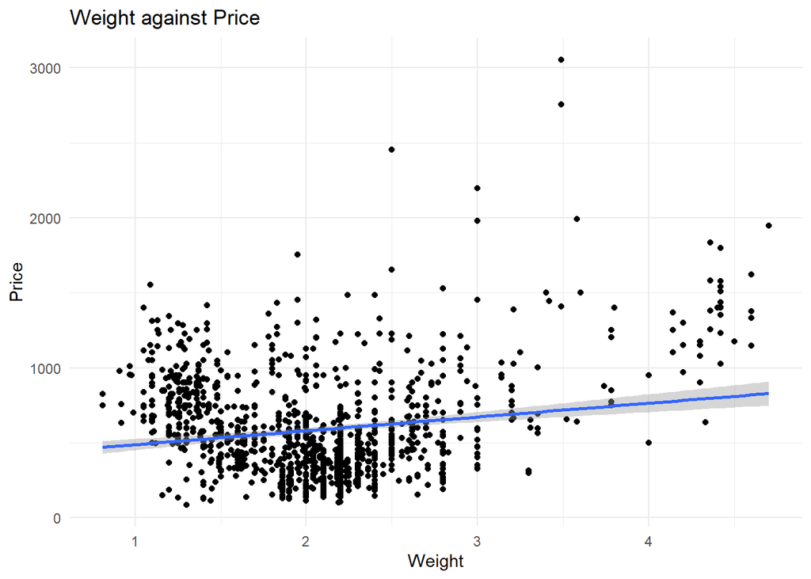

```r
laptop_data_final %>%
  ggplot(mapping = aes(x=Weight,y=Price,)) +
  geom_point() +
  geom_smooth(, method = "lm", )+
  theme_minimal() +
  labs(
    title = "Weight against Price",
    x = "Weight",
    y = "Price",
  )
```

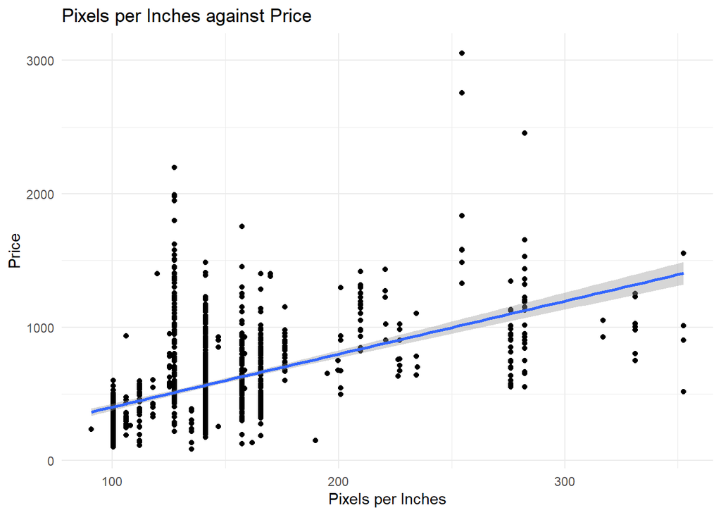

```r
laptop_data_final %>%
  ggplot(mapping = aes(x=Ppi,y=Price,)) +
  geom_point() +
  geom_smooth(, method = "lm", )+
  theme_minimal() +
  labs(
    title = "Pixels per Inches against Price",
    x = "Pixels per Inches",
    y = "Price",
  )
```

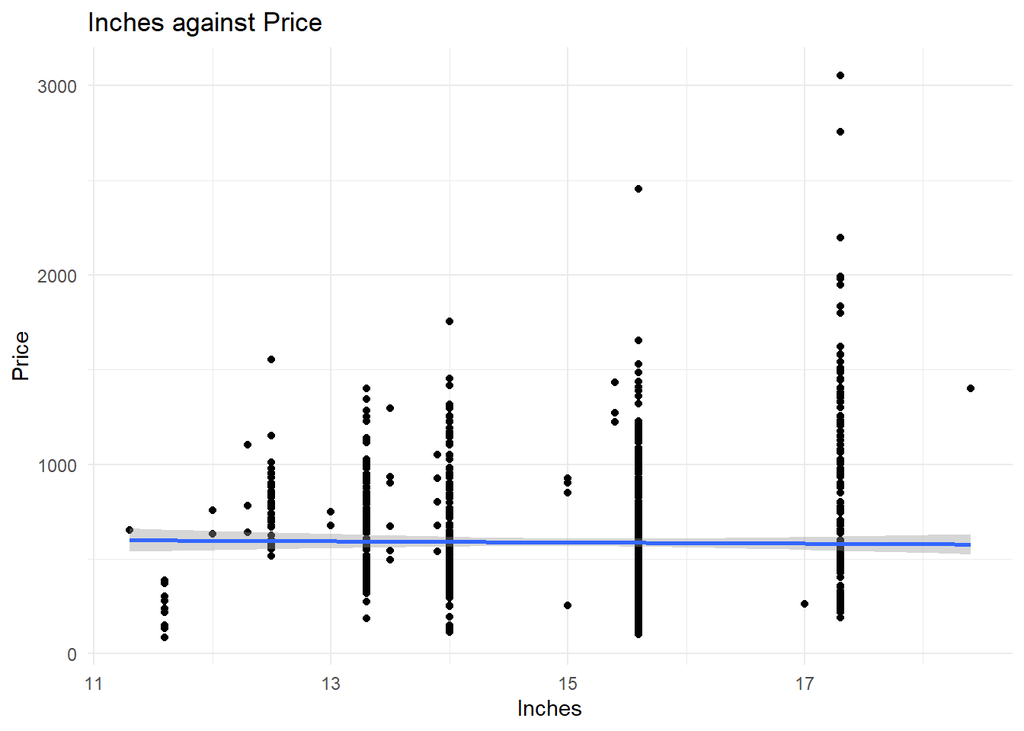

```r
laptop_data_final %>%
  ggplot(mapping = aes(x=Inches,y=Price,)) +
  geom_point() +
  geom_smooth(, method = "lm", )+
  theme_minimal() +
  labs(
    title = "Inches against Price",
    x = "Inches",
    y = "Price",
  )
```

[figure not shown]

```r
laptop_data_final %>%
  ggplot(mapping = aes(x=storage_capacity,y=Price,)) +
  geom_point() +
  geom_smooth(, method = "lm", )+
  theme_minimal() +
  labs(
    title = "Storage against Price",
    x = "Inches",
    y = "Price",
  )
```

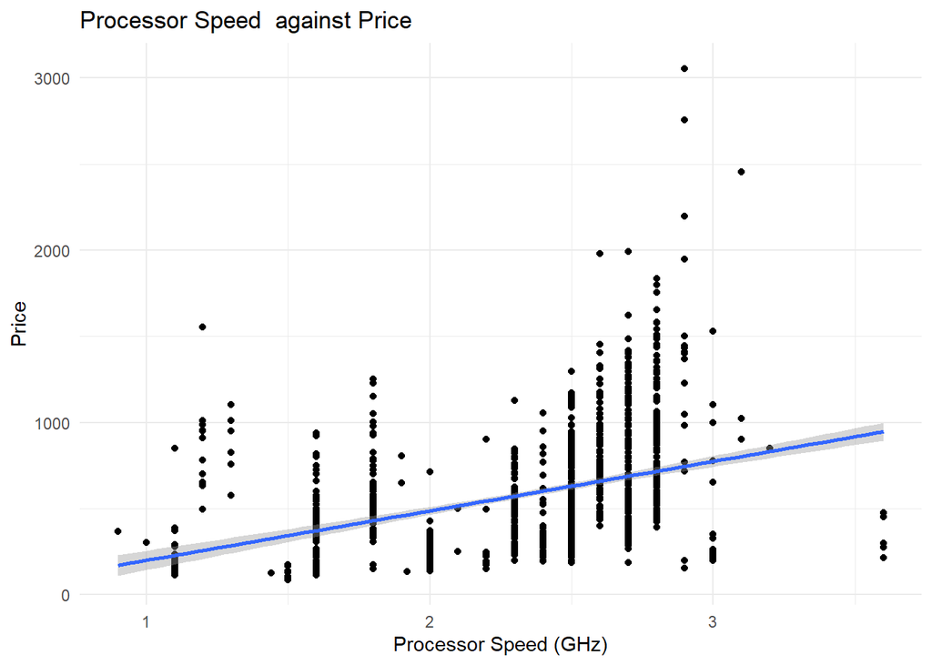

```r
laptop_data_final %>%
  ggplot(mapping = aes(x=GHz,y=Price,)) +
  geom_point() +
  geom_smooth(, method = "lm", )+
  theme_minimal() +
  labs(
    title = "Processor Speed  against Price",
    x = "Processor Speed (GHz)",
    y = "Price",
  )
```

Most of these have no linear relationship with price but in terms of numerical variables, RAM or Ppi is probably the best fit (I couldn’t figure out how to get these into a single plot so I did them all individually-Jamie)

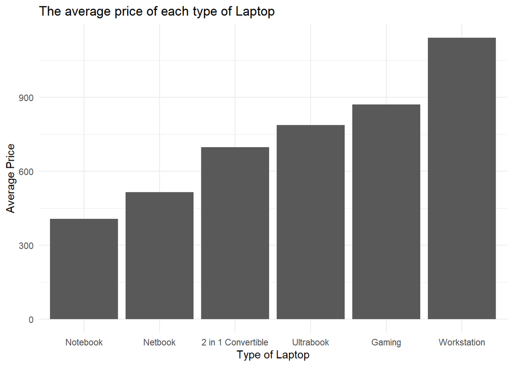

```r
averages_TypeName <-laptop_data_final %>%
  group_by(TypeName) %>%
  summarise(across(where(is.numeric), ~ mean(.x, na.rm = TRUE)))


averages_TypeName %>%
  ggplot(mapping = aes(x=reorder(TypeName,Price),y=Price,)) +
  geom_bar(stat = "identity") +
  theme_minimal() +
  labs(
    title = "The average price of each type of Laptop",
    x = "Type of Laptop",
    y = "Average Price",
  )
```

[figure not shown]

```r
averages_Company <-laptop_data_final %>%
  group_by(Company) %>%
  summarise(across(where(is.numeric), ~ mean(.x, na.rm = TRUE)))


averages_Company %>%
  ggplot(mapping = aes(x=reorder(Company,Price),y=Price,)) +
  geom_bar(stat = "identity") +
  theme_minimal() +
  labs(
    title = "The average price of each type of Laptop",
    x = "Laptop Provider ",
    y = "Average Price",
  )
```

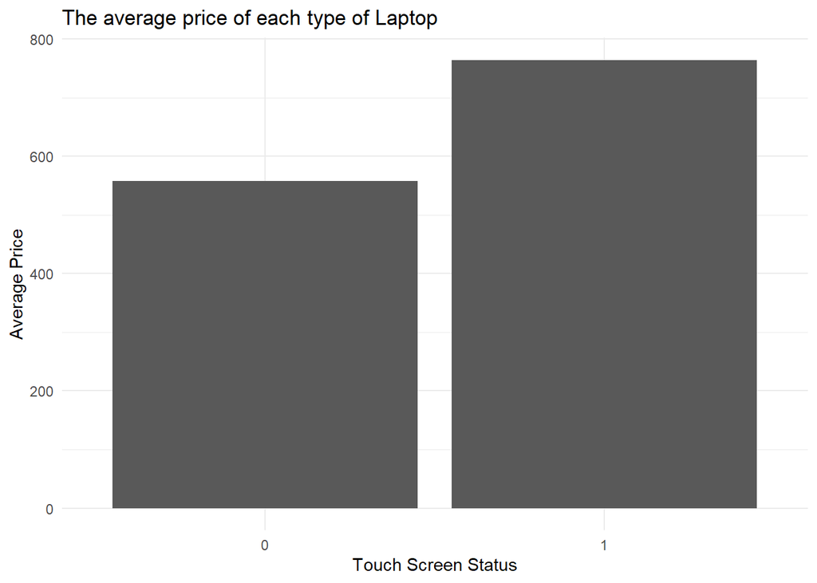

```r
average_TouchScreen <-laptop_data_final %>%
  group_by(TouchScreen) %>%
  summarise(across(where(is.numeric), ~ mean(.x, na.rm = TRUE)))


average_TouchScreen %>%
  ggplot(mapping = aes(x=reorder(TouchScreen,Price),y=Price,)) +
  geom_bar(stat = "identity") +
  theme_minimal() +
  labs(
    title = "The average price of each type of Laptop",
    x = "Touch Screen Status",
    y = "Average Price",
  )
```

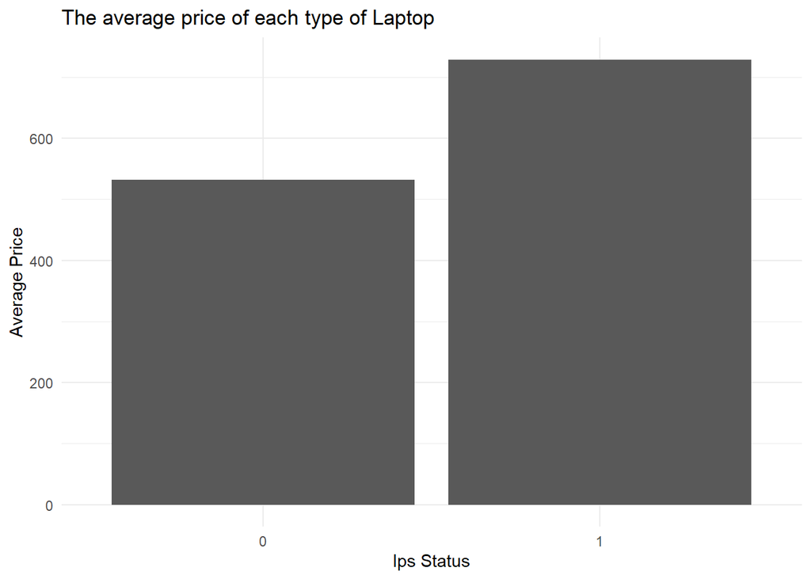

```r
average_Ips <-laptop_data_final %>%
  group_by(Ips) %>%
  summarise(across(where(is.numeric), ~ mean(.x, na.rm = TRUE)))


average_Ips %>%
  ggplot(mapping = aes(x=reorder(Ips,Price),y=Price,)) +
  geom_bar(stat = "identity") +
  theme_minimal() +
  labs(
    title = "The average price of each type of Laptop",
    x = "Ips Status",
    y = "Average Price",
  )
```

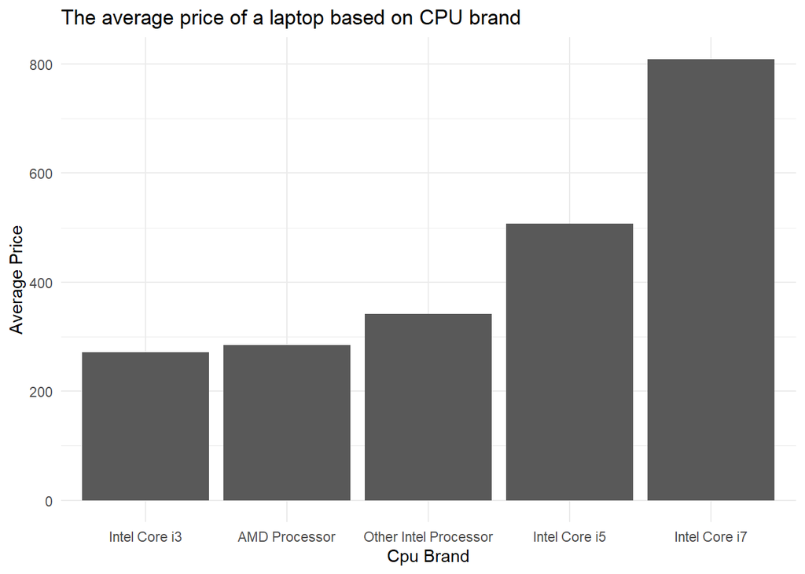

```r
average_CPU_Brand <-laptop_data_final %>%
  group_by(Cpu_brand) %>%
  summarise(across(where(is.numeric), ~ mean(.x, na.rm = TRUE)))


average_CPU_Brand %>%
  ggplot(mapping = aes(x=reorder(Cpu_brand,Price),y=Price,)) +
  geom_bar(stat = "identity") +
  theme_minimal() +
  labs(
    title = "The average price of a laptop based on CPU brand",
    x = "Cpu Brand",
    y = "Average Price",
  )
```

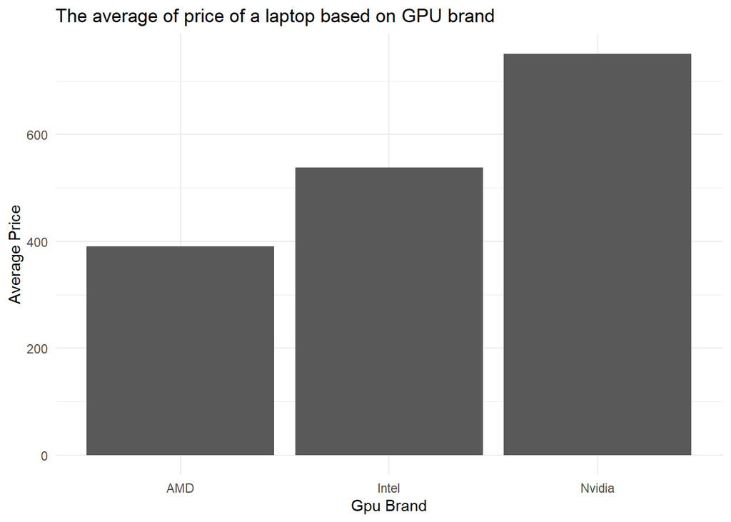

```r
average_GPU_Brand <-laptop_data_final %>%
  group_by(Gpu_brand) %>%
  summarise(across(where(is.numeric), ~ mean(.x, na.rm = TRUE)))


average_GPU_Brand %>%
  ggplot(mapping = aes(x=reorder(Gpu_brand,Price),y=Price,)) +
  geom_bar(stat = "identity") +
  theme_minimal() +
  labs(
    title = "The average of price of a laptop based on GPU brand",
    x = "Gpu Brand",
    y = "Average Price",
  )
```

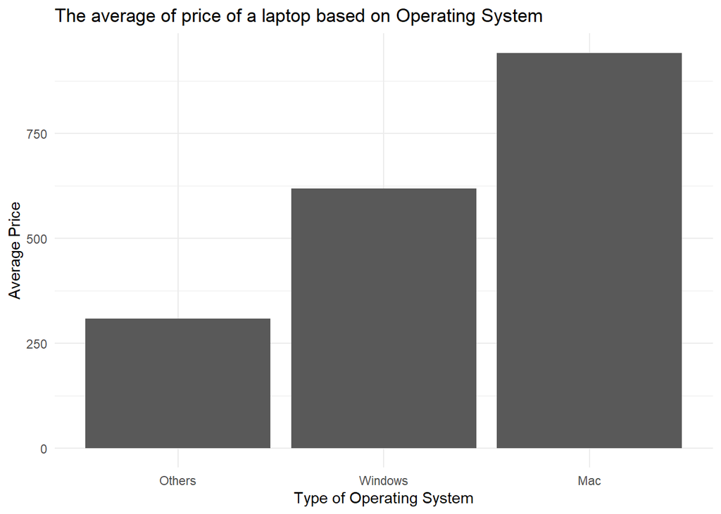

```r
average_Os <-laptop_data_final %>%
  group_by(Os) %>%
  summarise(across(where(is.numeric), ~ mean(.x, na.rm = TRUE)))


average_Os %>%
  ggplot(mapping = aes(x=reorder(Os,Price),y=Price,)) +
  geom_bar(stat = "identity") +
  theme_minimal() +
  labs(
    title = "The average of price of a laptop based on Operating System ",
    x = "Type of Operating System",
    y = "Average Price",
  )
```

[figure not shown]

```r
average_storage_type <-laptop_data_final %>%
  group_by(storage_type) %>%
  summarise(across(where(is.numeric), ~ mean(.x, na.rm = TRUE)))


average_storage_type %>%
  ggplot(mapping = aes(x=reorder(storage_type,Price),y=Price,)) +
  geom_bar(stat = "identity") +
  theme_minimal() +
  labs(
    title = "The average of price of a laptop based on Operating System ",
    x = "Type of Storage",
    y = "Average Price",
  )
```

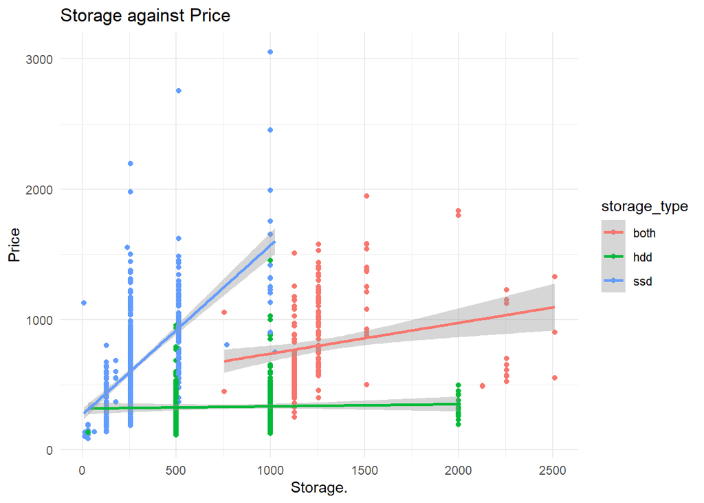

```r
laptop_data_company <- laptop_data_final %>%
  group_by(Company)

laptop_data_final %>%
  ggplot(mapping = aes(x=storage_capacity,y=Price,color = storage_type)) +
  geom_point() +
  geom_smooth(, method = "lm", )+
  theme_minimal() +
  labs(
    title = "Storage against Price",
    x = "Storage.",
    y = "Price",
  )
```

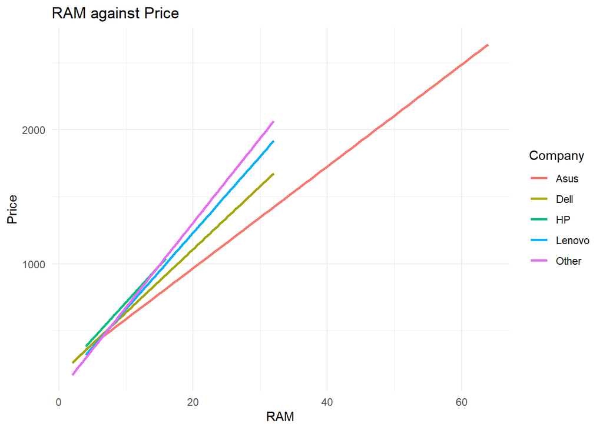

```r
laptop_data_company %>%
  ggplot(mapping = aes(x=Ram,y=Price, color=Company)) +
  geom_smooth(se = FALSE, method = "lm")+
  theme_minimal() +
  labs(
    title = "RAM against Price",
    x = "RAM",
    y = "Price",
    color = "Company"
  )
```

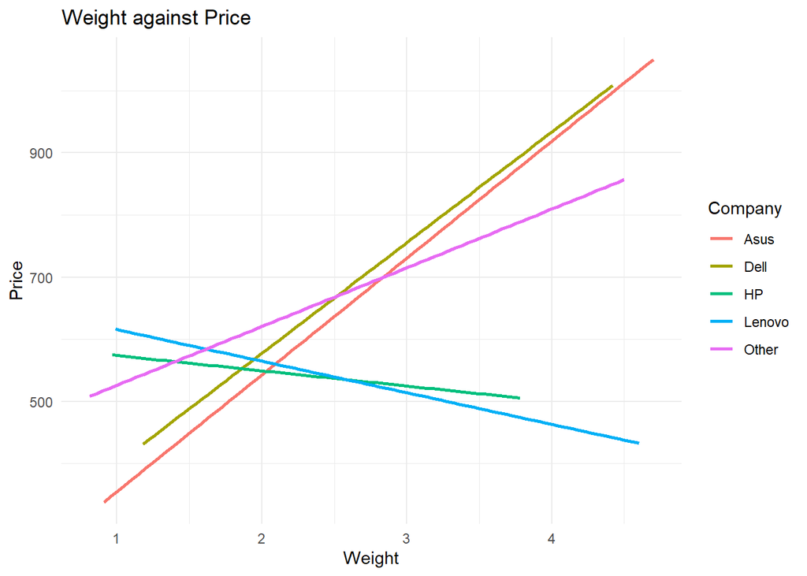

```r
laptop_data_company %>%
  ggplot(mapping = aes(x=Weight,y=Price, color=Company)) +
  geom_smooth(se = FALSE, method = "lm")+
  theme_minimal() +
  labs(
    title = "Weight against Price",
    x = "Weight",
    y = "Price",
  )
```

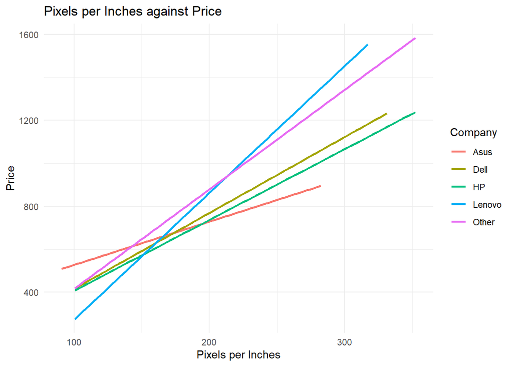

```r
laptop_data_company %>%
  ggplot(mapping = aes(x=Ppi,y=Price, color=Company)) +
  geom_smooth(se = FALSE, method = "lm")+
  theme_minimal() +
  labs(
    title = "Pixels per Inches against Price",
    x = "Pixels per Inches",
    y = "Price",
  )
```

==================